# R Lab: Logistic Regression

STA 631 – Statistical Modeling I

Author

Andrew DiLernia

Once completed, submit a zipped file (.zip) containing two total documents via Blackboard: a .qmd Quarto file and the corresponding HTML document.

In this assignment we will be analyzing data on demographic characteristics of states and state-level results for United States presidential elections from 2008 to 2024.

[figure not shown]

For this data, we will be concerned with the variables `year`, `state`, `prop_bachelors_or_higher`, `previous_election_winner`, and `winner`. A data dictionary for this data set is included below.

Table 1: Data dictionary for elections data set.

| Variable | Description |
| --- | --- |
| year | Year of the presidential election |
| state | Name of state |
| winner | Party of the winning candidate |
| previous_election_winner | Party of the winning candidate of the most recent prior election in the state |
| prop_bachelors_or_higher | Proportion of adults in the state whose highest attained education degree is a Bachelor's degree or higher (Bachelor's, Master's, Professional, or Doctoral) |

## 1

1. First, import data on presidential elections in the United States between 2008 and 2024 for this lab from https://raw.githubusercontent.com/dilernia/STA631/main/data/presidential_census.csv. Modify the `winner` variable to be a factor type with “Democrat” as the first or baseline category, and “Republican” the second category.
2. Create a new variable called `percent_bachelors_or_higher` that is `prop_bachelors_or_higher` multipled by 100.
3. Reproduce the clustered bar chart exactly as provided below. The colors used are #2673b6 and #d32628.

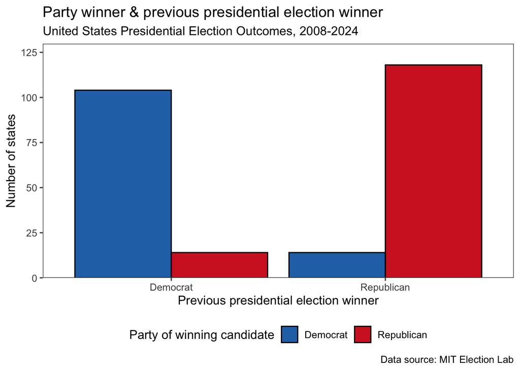

3. Reproduce the side-by-side box plots exactly as provided below. The colors used again are #2673b6 and #d32628.

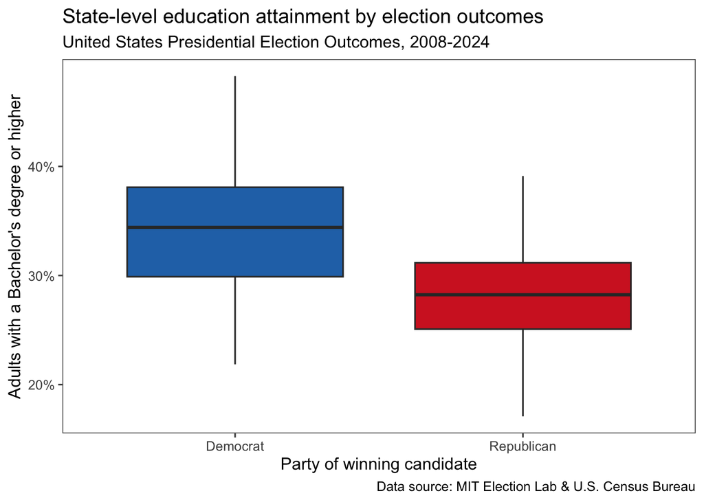

## 2

1. Fit a logistic regression model with whether a state was most recently won by a Democrat or Republican presidential candidate (`previous_election_winner`) and the percent of people with a Bachelor’s degree or higher (`percent_bachelors_or_higher`) as the predictor variables with whether a Republican won the presidential race or not as the response variable.
2. Reproduce the model output exactly as displayed below.

| **Characteristic** | **log(OR)** | **95% CI** | **p-value** | **VIF** |
| --- | --- | --- | --- | --- |
| (Intercept) | 1.1 | -1.6, 3.8 | 0.4 |  |
| previous_election_winner |  |  |  | 1.1 |
| Democrat | — | — |  |  |
| Republican | 3.7 | 2.9, 4.6 | <0.001 |  |
| percent_bachelors_or_higher | -0.09 | -0.18, -0.01 | 0.023 | 1.1 |

Abbreviations: CI = Confidence Interval, OR = Odds Ratio, VIF = Variance Inflation Factor  
Null deviance = 346; Null df = 249; Log-likelihood = -84.9; AIC = 176; BIC = 186; Deviance = 170; Residual df = 247; No. Obs. = 250

## 3

1. Give a formal statement of the estimated logistic regression model.

## 4

1. Obtain empirical logit plots for each predictor, specifying the `n_bins` argument to be 3.
2. Is the linearity assumption met for this logistic regression model? Why or why not?
3. Is the assumption of no significant multicollinearity met for this model? Why or why not?

## 5

1. Provide the value of **and interpret** the estimated slope for the indicator variable for `previous_election_winner` in context. Be specific in regards to the names of variables whenever possible.
2. Provide the value of **and interpret** the estimated slope for `percent_bachelors_or_higher` in context. Be specific in regards to the names of variables whenever possible.

## 6

1. Calculate the probability of a *Republican* winning a state that was most recently won by a Democrat with 40% of people in the state having attained a Bachelor’s degree or higher. Is this considered extrapolation?
2. Calculate the odds of a *Republican* winning a state that was most recently won by a Democrat with 40% of people in the state having attained a Bachelor’s degree or higher.
3. Calculate the probability of a *Democrat* winning a state that was most recently won by a Republican with 40% of people in the state having attained a Bachelor’s degree or higher. Is this considered extrapolation?